# Assignment 01

Mauricio Vazquez & Mariana Luna

2024-09-27

### Ex. 8.2: Modern Multivariate Statistical Techniques (Izenman)

Consider the wine data. Compute a LDA, draw a 2D-scatterplot of the first two LDF coordinates, and color-code the points by wine type. What do you notice?

```r
# Loading dataset
load("C:/Users/mauva/OneDrive/Documents/ITAM/9no Semestre/METODOS MULTIVARIADOS/REPOSITORIO/Multivariate_Statistical_Course_Assignments_Fall2024/ASSIGNMENT_01/wine.rda")

# Parsing to dataframe
wine_df <- as.data.frame(wine)

# Checking head dataset
head(wine_df)
```

```
##   Alcohol MalicAcid  Ash AlcAsh  Mg Phenols Flav NonFlavPhenols Proa Color  Hue
## 1   14.23      1.71 2.43   15.6 127    2.80 3.06           0.28 2.29  5.64 1.04
## 2   13.16      2.36 2.67   18.6 101    2.80 3.24           0.30 2.81  5.68 1.03
## 3   13.86      1.35 2.27   16.0  98    2.98 3.15           0.22 1.85  7.22 1.01
## 4   14.10      2.16 2.30   18.0 105    2.95 3.32           0.22 2.38  5.75 1.25
## 5   14.12      1.48 2.32   16.8  95    2.20 2.43           0.26 1.57  5.00 1.17
## 6   13.75      1.73 2.41   16.0  89    2.60 2.76           0.29 1.81  5.60 1.15
##     OD Proline classdigit  class
## 1 3.92    1065          1 Barolo
## 2 3.17    1185          1 Barolo
## 3 3.55    1045          1 Barolo
## 4 3.17    1510          1 Barolo
## 5 2.82    1280          1 Barolo
## 6 2.90    1320          1 Barolo
```

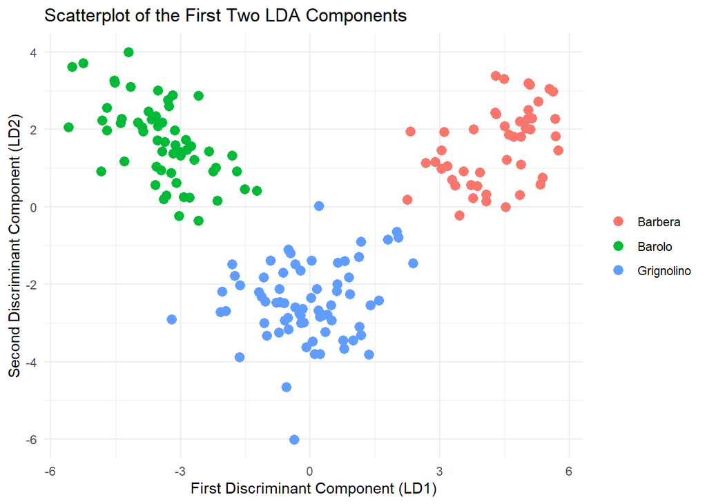

```r
# Parsing dataset column
wine_df$classdigit <- as.factor(wine_df$classdigit)

# Performing LDA
lda_model <- lda(classdigit ~ Alcohol + MalicAcid + Ash + AlcAsh + Mg + Phenols + Flav + NonFlavPhenols + Proa + Color + Hue + OD + Proline, data = wine_df)

# Projecting the data onto the LDA axes
lda_values <- predict(lda_model)

# Creating a data frame with the LDA components
lda_df <- data.frame(LD1 = lda_values$x[, 1], LD2 = lda_values$x[, 2], WineType = wine_df$class)

# Plotting
ggplot(lda_df, aes(x = LD1, y = LD2, color = WineType)) +
  geom_point(size = 3) +
  labs(title = "Scatterplot of the First Two LDA Components",
       x = "First Discriminant Component (LD1)",
       y = "Second Discriminant Component (LD2)") +
  theme_minimal() +
  theme(legend.title = element_blank())
```

### Ex. 8.3: Modern Multivariate Statistical Techniques (Izenman)

Suppose $X_1 \sim N_r(\mu_1, \Sigma_{XX})$ and $X_2 \sim N_r(\mu_2, \Sigma_{XX})$ are independently distributed. Consider the statistic:

$$\frac{(E(a^\tau X_1) - E(a^\tau X_2))^2}{\text{Var}(a^\tau X_1 - a^\tau
X_2)}$$

as a function of $a$. Show that $a \propto \Sigma_{XX}^{-1}(\mu_1 - \mu_2)$ maximizes the statistic using a Lagrange multiplier approach.

*Answer on PDF*

### Ex. 8.5: Modern Multivariate Statistical Techniques (Izenman)

Consider the diabetes data. Draw a scatterplot matrix of all five variables with different colors or symbols representing the three classes of diabetes. Do these pairwise plots suggest multivariate Gaussian distributions for each class with equal covariance matrices? Carry out an LDA and draw the 2D-scatterplot of the first two discriminating functions. Using the leave-one-out CV procedure, find the confusion table and identify those observations that are incorrectly classified based upon the LDA classification rule. Do the same for the QDA procedure.

```r
# Loading dataset
load("C:/Users/mauva/OneDrive/Documents/ITAM/9no Semestre/METODOS MULTIVARIADOS/REPOSITORIO/Multivariate_Statistical_Course_Assignments_Fall2024/ASSIGNMENT_01/diabetes.rda")

# Parsing to dataframe
diabetes_df <- as.data.frame(diabetes)

# Checking head dataset
head(diabetes_df)
```

```
##   glucose.area insulin.area SSPG relative.weight fasting.plasma.glucose class
## 1         0.81           80  356             124                     55     3
## 2         0.95           97  289             117                     76     3
## 3         0.94          105  319             143                    105     3
## 4         1.04           90  356             199                    108     3
## 5         1.00           90  323             240                    143     3
## 6         0.76           86  381             157                    165     3
```

### Ex. 12.2: Modern Multivariate Statistical Techniques (Izenman)

Write a computer program to implement single-linkage, averagelinkage, and complete-linkage agglomerative hierarchical clustering. Try it out on a data set of your choice.

```r
# Loading dataset
load("C:/Users/mauva/OneDrive/Documents/ITAM/9no Semestre/METODOS MULTIVARIADOS/REPOSITORIO/Multivariate_Statistical_Course_Assignments_Fall2024/ASSIGNMENT_01/wine.rda")

# Parsing to dataframe
wine_df <- as.data.frame(wine)

# Checking head dataset
head(wine_df)
```

```
##   Alcohol MalicAcid  Ash AlcAsh  Mg Phenols Flav NonFlavPhenols Proa Color  Hue
## 1   14.23      1.71 2.43   15.6 127    2.80 3.06           0.28 2.29  5.64 1.04
## 2   13.16      2.36 2.67   18.6 101    2.80 3.24           0.30 2.81  5.68 1.03
## 3   13.86      1.35 2.27   16.0  98    2.98 3.15           0.22 1.85  7.22 1.01
## 4   14.10      2.16 2.30   18.0 105    2.95 3.32           0.22 2.38  5.75 1.25
## 5   14.12      1.48 2.32   16.8  95    2.20 2.43           0.26 1.57  5.00 1.17
## 6   13.75      1.73 2.41   16.0  89    2.60 2.76           0.29 1.81  5.60 1.15
##     OD Proline classdigit  class
## 1 3.92    1065          1 Barolo
## 2 3.17    1185          1 Barolo
## 3 3.55    1045          1 Barolo
## 4 3.17    1510          1 Barolo
## 5 2.82    1280          1 Barolo
## 6 2.90    1320          1 Barolo
```

```r
# Compute distance matrix
dist_matrix <- dist(wine_df)
# Single linkage clustering
single_linkage <- hclust(dist_matrix, method = "single")

# Average linkage clustering
average_linkage <- hclust(dist_matrix, method = "average")

# Complete linkage clustering
complete_linkage <- hclust(dist_matrix, method = "complete")

dev.off()
```

```r
plot(single_linkage, main = "Single Linkage", sub = "", xlab = "", ylab = "Height")
plot(average_linkage, main = "Average Linkage", sub = "", xlab = "", ylab = "Height")
plot(complete_linkage, main = "Complete Linkage", sub = "", xlab = "", ylab = "Height")
```

[output not shown]

### Ex. 12.3: Modern Multivariate Statistical Techniques (Izenman)

Cluster the primate.scapulae data using single-linkage, averagelinkage, and complete-linkage agglomerative hierarchical clustering methods. Find the five-cluster solutions for all three methods, which allows comparison with the true primate classifications. Find the misclassification rate for all three methods. Show that the lowest rate occurs for the completelinkage method and the highest for the single-linkage method.

### Ex. 11.1: Applied Multivariate Statistical Analysis (Johnson & Wichern)

### Ex. 11.3: Applied Multivariate Statistical Analysis (Johnson & Wichern)

### Ex. 11.5: Applied Multivariate Statistical Analysis (Johnson & Wichern)

### Ex. 12.1: Applied Multivariate Statistical Analysis (Johnson & Wichern)

### Ex. 12.11: Applied Multivariate Statistical Analysis (Johnson & Wichern)

We measure two variables $X_1$ and $X_2$ for four items $A$, $B$, $C$, and $D$. The observations are as follows:

| Item | $X_1$ | $X_2$ |
| --- | --- | --- |
| A | 5 | 4 |
| B | 1 | -2 |
| C | -1 | 1 |
| D | 3 | 1 |

We are tasked to use the **K-means clustering** technique to divide the items into $K = 2$ clusters, starting with the initial groups (AB) and (CD).

```r
# Create the dataset with items A, B, C, and D
data <- data.frame(
  Item = c("A", "B", "C", "D"),
  X1 = c(5, 1, -1, 3),
  X2 = c(4, -2, 1, 1)
)

# Display the dataset
print(data)
```

```
##   Item X1 X2
## 1    A  5  4
## 2    B  1 -2
## 3    C -1  1
## 4    D  3  1
```

```r
# Define the initial positions of the cluster centers
initial_centers <- data.frame(
  X1 = c(mean(c(5, 1)), mean(c(-1, 3))),
  X2 = c(mean(c(4, -2)), mean(c(1, 1)))
)

# Display the initial centers
print(initial_centers)
```

```
##   X1 X2
## 1  3  1
## 2  1  1
```

```r
# Perform k-means clustering using the initial centers
set.seed(123)
kmeans_result <- kmeans(data[, c("X1", "X2")], centers = initial_centers)

# Display the clustering results
cat("Cluster assignments:\n")
```

```
## Cluster assignments:
```

```r
print(kmeans_result$cluster)
```

```
## [1] 1 2 2 1
```

```r
cat("\nCluster centers:\n")
```

```
##
## Cluster centers:
```

```r
print(kmeans_result$centers)
```

```
##   X1   X2
## 1  4  2.5
## 2  0 -0.5
```

### Ex. 5.1: Deep Learning: Foundations and Concepts (Bishop & Bishop)

### Ex. 5.6: Deep Learning: Foundations and Concepts (Bishop & Bishop)

### Ex. 5.12: Deep Learning: Foundations and Concepts (Bishop & Bishop)

### Ex. 15.2: Deep Learning: Foundations and Concepts (Bishop & Bishop)

### Ex. 15.3: Deep Learning: Foundations and Concepts (Bishop & Bishop)